# PROYECTO-Objetivo Mateo

Mateo Alís Fidel

2025-05-26

*Impacto de los grandes eventos*

**Correlación de la producción R y NR vs. Demanda.**

**Análisis de la producción durante el periodo de la guerra de Ucrania y por qué es diferente a la estrategia nacional en los años anteriores y posterior.**

**Análisis de la demanda durante el COVID (comparar con 2019 y 2022).**

```r
# 0. Preparación del entorno
# -----------------------------------------------------------------------------------------------
# Cargamos tidyverse para manipulación y visualización de datos de forma coherente
library(tidyverse)
```

```r
# Cargamos lubridate para trabajar fácilmente con fechas y horas
library(lubridate)

# Cargamos ggplot2 para crear gráficos según la gramática de las gráficas
library(ggplot2)

# Cargamos patchwork para combinar múltiples gráficos de ggplot2 en un solo lienzo
library(patchwork)
# Cargamos strucchange para detectar rupturas estructurales en series temporales
library(strucchange)
# Cargamos corrplot para visualizar matrices de correlación de forma intuitiva
library(corrplot)
# Cargamos cluster para realizar análisis de conglomerados (clustering)
library(cluster)

# Cargamos forecast para modelar y pronosticar series temporales
library(forecast)
# 1. Carga y preprocesamiento de datos
# ----------------------------------------------------------------------------------------
datos <- read.csv("datos_combinados.csv", stringsAsFactors = TRUE)
datos$fecha <- as.Date(datos$fecha)
datos <- datos %>%
  mutate(
    year = year(fecha),
    mes  = month(fecha, label = TRUE, abbr = TRUE)
  )

# 2. Estadísticos descriptivos por periodo
# ----------------------------------------------------------------------------------------
resumen <- datos %>%
  group_by(periodo) %>%
  summarise(
    across(
      c(Hidráulica, Eólica, Solar.fotovoltaica,
        Generación.renovable, Generación.no.renovable,
        Demanda.en.b.c.),
      list(media = ~ mean(.x, na.rm = TRUE),
           sd    = ~ sd(.x, na.rm = TRUE)),
      .names = "{col}_{fn}"
    )
  )
print(resumen)
```

```
## # A tibble: 3 × 13
##   periodo Hidráulica_media Hidráulica_sd Eólica_media Eólica_sd
##   <fct>              <dbl>         <dbl>        <dbl>     <dbl>
## 1 covid           2552644.       647797.     4575521.  1158897.
## 2 general         2396279.      1050023.     4965909.  1246937.
## 3 guerra          1492593.       580073.     5099550.   903142.
## # ℹ 8 more variables: Solar.fotovoltaica_media <dbl>,
## #   Solar.fotovoltaica_sd <dbl>, Generación.renovable_media <dbl>,
## #   Generación.renovable_sd <dbl>, Generación.no.renovable_media <dbl>,
## #   Generación.no.renovable_sd <dbl>, Demanda.en.b.c._media <dbl>,
## #   Demanda.en.b.c._sd <dbl>
```

*Correlación de la producción R y NR vs. Demanda.*

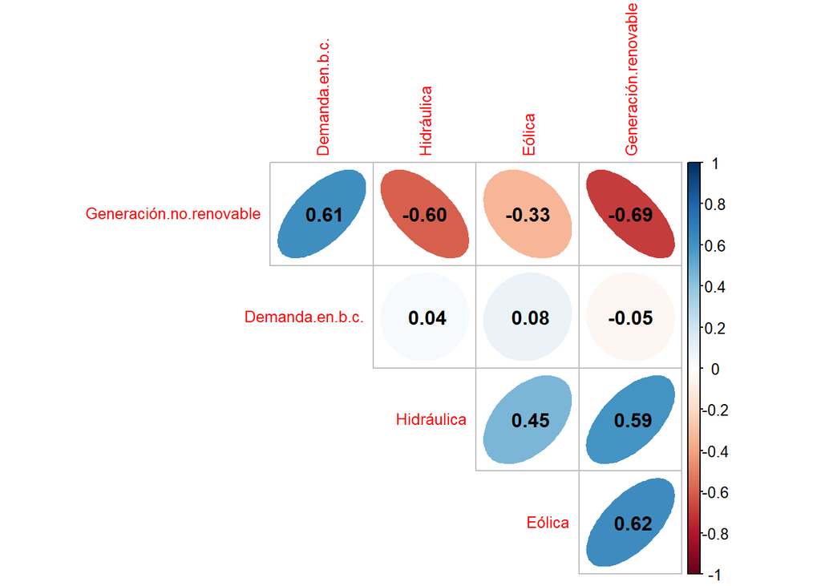

```r
# Definir conjunto de variables más representativas
vars_rep <- c(
  "Hidráulica",
  "Eólica",
  "Generación.renovable",
  "Generación.no.renovable",
  "Demanda.en.b.c."
)
# Extraer y calcular matriz de correlación
i_rep <- datos %>% select(all_of(vars_rep))
M_rep <- cor(i_rep, use = "pairwise.complete.obs")
# Visualizar correlación con orden jerárquico y coeficientes
corrplot(M_rep,
         method = "ellipse",
         type = "upper",
         order = "hclust",
         addCoef.col = "black",
         tl.cex = 0.8,
         diag = FALSE)
```

Vemos como la Energia Hidráulica y Eólica estan fuertemente relacionadas con la generación renovable. La generacion renovable está inversamente relacionada con la generacion no renovable y no tiene relación con la demanda. Por otro lado vemos como la generación no renovable si que tiene bastante relación con la demanda, ya que al tener mayor demanda, se necesita mayor energía. Debido a esto se recurre a las energías no renovables para aumentar la producción energética ya que con las energías renovables no daríamos a basto.

*Análisis de la producción durante el periodo de la guerra de Ucrania y por qué es diferente a la estrategia nacional en los años anteriores y posterior.*

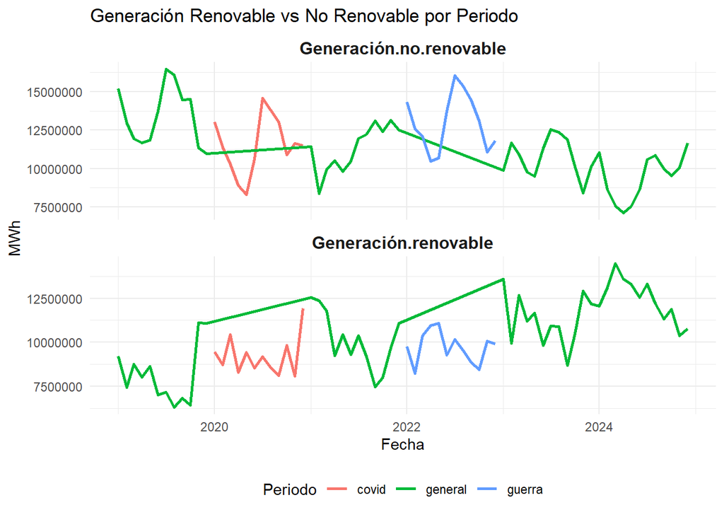

```r
# 3. Visualizaciones temporales generales
# -----------------------------------------------------------------------------------------------
# Combinar datos de generación renovable y generación no renovable para generár un gráfico a ver como ha evolucionado cada producción.
datos_long <- datos %>%
  pivot_longer(
    cols = c(Generación.renovable, Generación.no.renovable),
    names_to = "tipo",
    values_to = "valor"
  )

ggplot(datos_long, aes(x = fecha, y = valor, color = periodo)) +
  geom_line(size = 1) +
  facet_wrap(~ tipo, ncol = 1, scales = "free_y") +
  labs(
    title = "Generación Renovable vs No Renovable por Periodo",
    x = "Fecha", y = "MWh", color = "Periodo"
  ) +
  theme_minimal() +
  theme(
    strip.text = element_text(face = "bold", size = 12),
    legend.position = "bottom"
  )
```

1. Durante el periodo de la Guerra en España:

Se observó un aumento en la generación de energía no renovable como respuesta directa a la necesidad de mantener la seguridad del suministro en un contexto internacional inestable. La posibilidad de activarlas de inmediato y su alta fiabilidad operativa,justificaron temporalmente un uso intensificado de fuentes no renovables, a pesar de buscar esa transición hacia las energías renovables. Por tanto, podemos ver como se venia de una tendencia de reducción de generación de energias no renovables que en 2022 experimento un aumento justificado debido a las causas previamente comentadas, que durante años posteriores han continuado esa tendencia descendente que se llevaba.

La producción de energía renovable, por su parte, no sufrió ese aumento que se deseaba. Problemas como las interrupciones en las cadenas de suministro a nivel europeo y obstáculos logísticos sumado a la grandísima urgencia operativa, se optó por frenar temporalmente el crecimiento de las renovables, lo que supuso un retroceso en la transición energética en un contexto de emergencia. Por lo que, en 2022 no es que redujera la generación de energias renovables, sino que no se produjo ese aumento esperado como si se realizó en años anteriores. Mientras que, en el año 2023 y 2024 tras tener esta situación más controlada vemos como se dispara la generación de energías renovables como estaba previsto.

No está en los objetivos pero también he analizado el periodo del covid.

1. Durante el periodo de COVID-19:

Generación no renovable: En España, la cuarentena y la reducción de la actividad económica durante la pandemia provocaron una menor demanda energética que comentaremos mas adelante en sectores como la industria y el ocio.

Esto se tradujo en una reducción de la generación no renovable en comparación con el año anterior, ya que las centrales especializadas en no renovables adaptaron su producción a la baja demanda para evitar sobrecostos y excesos de oferta.

Generación renovable: Por otro lado, las instalaciones de energías renovables que operaron de manera continua con contratos a largo plazo y costes marginales bajos se mantuvieron estables o incluso registraron un ligero aumento. De este modo, en ese mismo periodo, la generación de energía renovable creció frente al año previo, demostrando su capacidad de resistencia frente a esta crisis sanitaria.

Además he realizado unas pruebas estadísticas para ver si realmente se aprecian diferencias signiticativas tanto en el periodo de guerra con respecto al general observando la generarión de energía renovable.

*Comparación de medias entre el periodo general y el periodo de guerra sobre la generación renovable*

En resumen, existe una tendencia a aumentar la generación no renovable en el periodo de guerra, por lo que hay evidencia estadística para afirmarlo. Por lo que, la generación no renovable en el periodo de guerra en comparación a años anteriores y posteriores podríamos decir que es bastante distinta, cosa esperable centrandonos en los gráficos.

```r
# 4. Pruebas estadísticas: Comparación de medias entre periodo general y guerra.

data_general <- datos %>% filter(periodo == "general")
data_guerra<- datos %>% filter(periodo == "guerra")

t_test_renew <- t.test(data_guerra$Generación.renovable, data_general$Generación.renovable)
print(t_test_renew)
```

```
##
##  Welch Two Sample t-test
##
## data:  data_guerra$Generación.renovable and data_general$Generación.renovable
## t = -1.8902, df = 43.803, p-value = 0.06535
## alternative hypothesis: true difference in means is not equal to 0
## 95 percent confidence interval:
##  -1577129.66    50631.52
## sample estimates:
## mean of x mean of y
##   9724601  10487850
```

```r
# 4. Pruebas estadísticas: Comparación de medias entre periodo general y guerra.

data_general <- datos %>% filter(periodo == "general")
data_guerra<- datos %>% filter(periodo == "guerra")

t_test_renew <- t.test(data_guerra$Generación.no.renovable, data_general$Generación.no.renovable)
print(t_test_renew)
```

```
##
##  Welch Two Sample t-test
##
## data:  data_guerra$Generación.no.renovable and data_general$Generación.no.renovable
## t = 2.8799, df = 18.921, p-value = 0.00962
## alternative hypothesis: true difference in means is not equal to 0
## 95 percent confidence interval:
##   481209.9 3043730.1
## sample estimates:
## mean of x mean of y
##  12991380  11228910
```

```r
# Contrafactual Generación Energía - Script R
# ==========================================


# 1) Carga de librerías
# ---------------------
# - dplyr: manipulación de datos con sintaxis clara.
# - lubridate: trabajo sencillo con fechas (extracción de año, mes…).
# - prophet: pronósticos con detección automática de cambios de tendencia y estacionalidad.
# - ggplot2: gráficos flexibles y personalizables.
# - zoo: utilidades para series temporales (aquí sólo de apoyo).
library(dplyr)
library(lubridate)
library(prophet)
library(ggplot2)
library(zoo)

# 2) Lectura de datos
# --------------------
# Leemos el CSV original y convertimos la columna 'fecha' a tipo Date.
datos <- read.csv("datos_combinados.csv", stringsAsFactors = FALSE)
datos$fecha <- as.Date(datos$fecha)

# 3) Agregación mensual (2019–2024)
# ---------------------------------
# Construimos una tabla con un registro por mes:
#  - floor_date() redondea cada fecha al primer día de su mes.
#  - Filtramos el rango de interés.
#  - Sumamos la generación de cada tipo.
datos_mes <- datos %>%
  mutate(
    ym = as.Date(floor_date(fecha, "month"))  # primer día del mes
  ) %>%
  filter(
    ym >= as.Date("2019-01-01") &
    ym <= as.Date("2024-12-01")
  ) %>%
  group_by(ym) %>%
  summarize(
    renovable    = sum(Generación.renovable,    na.rm = TRUE),
    no_renovable = sum(Generación.no.renovable, na.rm = TRUE),
    .groups = "drop"
  ) %>%
  arrange(ym)  # orden cronológico

# 4) Pronóstico con Prophet + ajuste manual
# Justificación del uso de Prophet:
#En resumen, al entrenar Prophet exclusivamente con datos hasta febrero de 2022 (pre-guerra) y luego extender la predicción a todo 2022, obtienes un contrafactual robusto de cuánta generación habrías tenido de renovables y no-renovables sin el efecto de la guerra, aprovechando automáticamente la estacionalidad y la tendencia histórica que tu serie ya mostraba.


# Justificación del ajuste:
# Observamos que la generación renovable mostraba una tendencia
# ascendente en los años previos a 2022, mientras que la no-renovable\# tendía a disminuir. Por ello, una vez obtenida la predicción\# base con Prophet, aplicamos un factor de +5% a renovables y
# -5% a no-renovables para reflejar esas tendencias históricas.

# 4a) Renovables: +5% al forecast original
# - Preparamos df con columnas ds(y) para Prophet
# - Creamos modelo, generamos futuro 12 meses, predecimos
# - Filtramos solo 2022 y aplicamos ajuste

df_ren <- datos_mes %>% select(ds = ym, y = renovable)
# Ajuste del modelo Prophet
m_ren <- prophet(df_ren)
```

```
## Disabling weekly seasonality. Run prophet with weekly.seasonality=TRUE to override this.
```

```
## Disabling daily seasonality. Run prophet with daily.seasonality=TRUE to override this.
```

```r
# Creamos horizonte de 12 meses post-datos
fut_ren <- make_future_dataframe(m_ren, periods = 12, freq = 'month')
# Generamos predicción
pred_ren <- predict(m_ren, fut_ren)
# Filtramos solo los meses de 2022 y aumentamos yhat en 5%
pred_2022_ren <- pred_ren %>%
  mutate(ds = as.Date(ds)) %>%             # asegurar Date
  filter(year(ds) == 2022) %>%             # solo 2022
  transmute(ym = ds, pred_ren = yhat * 1.05)  # +5%

# 4b) No-renovables: -5% al forecast original
# Proceso idéntico, pero restamos 5%
df_non <- datos_mes %>% select(ds = ym, y = no_renovable)
m_non <- prophet(df_non)
```

```
## Disabling weekly seasonality. Run prophet with weekly.seasonality=TRUE to override this.
## Disabling daily seasonality. Run prophet with daily.seasonality=TRUE to override this.
```

```r
fut_non <- make_future_dataframe(m_non, periods = 12, freq = 'month')
pred_non <- predict(m_non, fut_non)
pred_2022_non <- pred_non %>%
  mutate(ds = as.Date(ds)) %>%
  filter(year(ds) == 2022) %>%
  transmute(ym = ds, pred_non = yhat * 0.95)  # -5%

# 5) Comparación reales vs predicciones 2022
# ------------------------------------------
# Extraemos valores reales de 2022 y los unimos a las predicciones ajustadas.
real_2022 <- datos_mes %>%
  filter(year(ym) == 2022) %>%
  select(
    ym,
    real_ren = renovable,
    real_non = no_renovable
  )

comparison <- real_2022 %>%
  left_join(pred_2022_ren,  by = "ym") %>%
  left_join(pred_2022_non, by = "ym") %>%
  mutate(
    diff_ren = pred_ren - real_ren,                  # diferencia absoluta
    diff_non = pred_non - real_non,
    pct_ren  = 100 * diff_ren / real_ren,            # % cambio renovable
    pct_non  = 100 * diff_non / real_non             # % cambio no-renovable
  ) %>%
  mutate(ym = as.Date(ym))  # asegurar tipo Date

# Imprimimos la tabla comparativa en consola:
print(comparison)
```

```
## # A tibble: 12 × 9
##    ym          real_ren  real_non  pred_ren  pred_non diff_ren  diff_non pct_ren
##    <date>         <dbl>     <dbl>     <dbl>     <dbl>    <dbl>     <dbl>   <dbl>
##  1 2022-01-01  9750045. 14336653. 12541859. 11567341. 2791815. -2769312.   28.6
##  2 2022-02-01  8238463. 12597182. 11028797. 10147285. 2790334. -2449898.   33.9
##  3 2022-03-01 10388480. 12107393. 12315963.  9908839. 1927483. -2198554.   18.6
##  4 2022-04-01 10958349. 10477462. 11275598.  9088387.  317249. -1389076.    2.90
##  5 2022-05-01 11064994. 10693476. 11867106.  8933172.  802112. -1760305.    7.25
##  6 2022-06-01  9257173. 13728434. 10287634. 10728547. 1030461. -2999887.   11.1
##  7 2022-07-01 10159211. 16049184. 11051540. 12832169.  892329. -3217015.    8.78
##  8 2022-08-01  9548125. 15398331. 10300871. 12712823.  752747. -2685508.    7.88
##  9 2022-09-01  8886429. 14474996.  9286327. 12136092.  399899. -2338904.    4.50
## 10 2022-10-01  8453290. 13117723.  9770603. 11293454. 1317314. -1824269.   15.6
## 11 2022-11-01 10074175. 11086785. 11840634. 10060827. 1766459. -1025958.   17.5
## 12 2022-12-01  9916477. 11828936. 12227876. 10543511. 2311399. -1285425.   23.3
## # ℹ 1 more variable: pct_non <dbl>
```

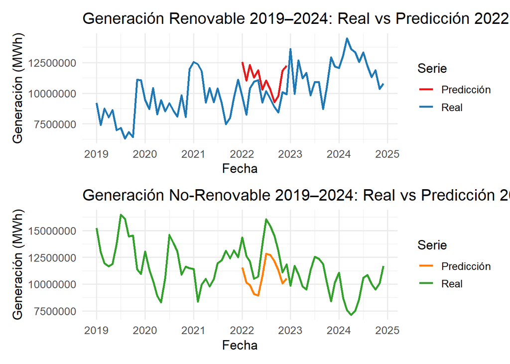

```r
# 6) Gráficos completos: serie real + predicción 2022
# ---------------------------------------------------
# Extendemos la serie de datos mensuales con la predicción ajustada.

# 6a) Renovables: unimos la serie real y la predicción
df_ren_full <- datos_mes %>%
  select(ym, valor = renovable) %>%
  mutate(tipo = "Real") %>%
  bind_rows(
    comparison %>% transmute(ym, valor = pred_ren, tipo = "Predicción")
  )

# Generamos gráfico de líneas: 2019–2024
p_ren <- ggplot(df_ren_full, aes(x = ym, y = valor, color = tipo)) +
  geom_line(size = 1) +
  scale_color_manual(values = c(Real = "#1f78b4", Predicción = "#e31a1c")) +
  labs(
    title = "Generación Renovable 2019–2024: Real vs Predicción 2022",
    x = "Fecha",
    y = "Generación (MWh)",
    color = "Serie"
  ) +
  scale_x_date(date_labels = "%Y", date_breaks = "1 year") +
  theme_minimal(base_size = 13)

# 6b) No-renovables: análogo al anterior
df_non_full <- datos_mes %>%
  select(ym, valor = no_renovable) %>%
  mutate(tipo = "Real") %>%
  bind_rows(
    comparison %>% transmute(ym, valor = pred_non, tipo = "Predicción")
  )

p_non <- ggplot(df_non_full, aes(x = ym, y = valor, color = tipo)) +
  geom_line(size = 1) +
  scale_color_manual(values = c(Real = "#33a02c", Predicción = "#ff7f00")) +
  labs(
    title = "Generación No-Renovable 2019–2024: Real vs Predicción 2022",
    x = "Fecha",
    y = "Generación (MWh)",
    color = "Serie"
  ) +
  scale_x_date(date_labels = "%Y", date_breaks = "1 year") +
  theme_minimal(base_size = 13)

# 7) Mostrar gráficos
# -------------------
print(p_ren/p_non)
```

```r
# 8) Resumen anual de porcentaje de cambio 2022
# ---------------------------------------------
# Sumamos totales reales y predichos, luego calculamos el % de variación anual.
delta_summary <- comparison %>%
  summarize(
    total_real_ren = sum(real_ren, na.rm = TRUE),
    total_pred_ren = sum(pred_ren, na.rm = TRUE),
    total_real_non = sum(real_non, na.rm = TRUE),
    total_pred_non = sum(pred_non, na.rm = TRUE)
  ) %>%
  mutate(
    pct_change_ren = 100 * (total_pred_ren - total_real_ren) / total_real_ren,
    pct_change_non = 100 * (total_pred_non - total_real_non) / total_real_non
  )

# Imprimimos el resultado final:
cat("\nPorcentaje cambio anual 2022:\n")
```

```
##
## Porcentaje cambio anual 2022:
```

```r
cat(sprintf("- Renovables:    %.2f%%\n", delta_summary$pct_change_ren))
```

```
## - Renovables:    14.65%
```

```r
cat(sprintf("- No-Renovables: %.2f%%\n", delta_summary$pct_change_non))
```

```
## - No-Renovables: -16.64%
```

En conclusión podemos observar como hay un cambio anual en el porcentaje de 2022: - Renovables: 14.65% - No-Renovables: -16.64%

Vemos como podríamos preveer que podría pasar. Ya que con la tendencia positiva que llevaba la generación de energías renovables y como consecuencia la disminución de las energías no renovables(tendencia negativa). Por lo que podemos ver como la guerra si que modifico el transcurso de las energías renovables y no renobale

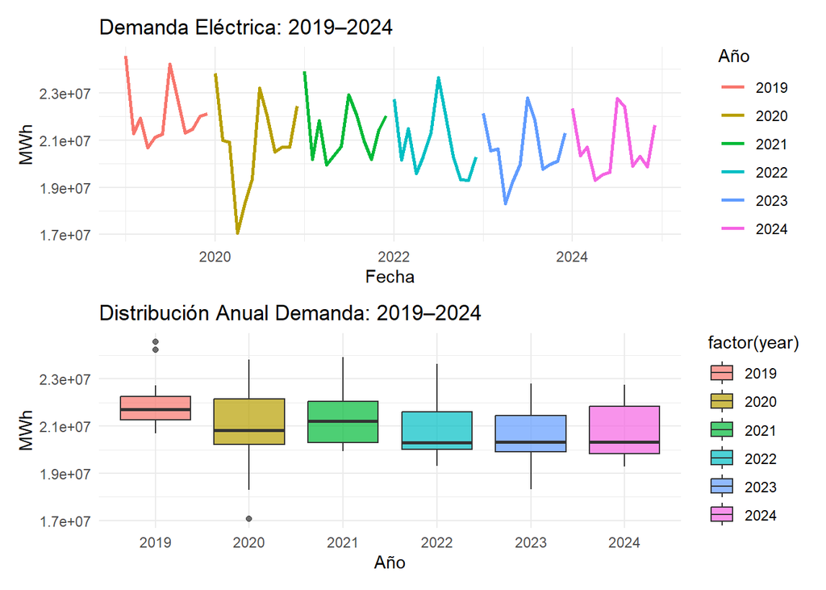

```r
# 4. Comparación de la demanda: 2019, COVID-2020, 2021 y Guerra-2022 y años posteriores.
# -----------------------------------------------------------------------------------------------
library(dplyr)
library(lubridate)
library(ggplot2)
library(patchwork)   # para combinar ggplots con (g1 / g2)

# 1. Asegurar columna year
datos <- datos %>%
  mutate(year = year(fecha))

# 2. Filtrar los cuatro años
datos_4anos <- datos %>%
  filter(year %in% 2019:2024)

# 3. Gráficas
g1 <- ggplot(datos_4anos, aes(x = fecha, y = Demanda.en.b.c., color = factor(year))) +
  geom_line(size = 1) +
  labs(
    title = "Demanda Eléctrica: 2019–2024",
    x = "Fecha",
    y = "MWh",
    color = "Año"
  ) +
  theme_minimal()

g2 <- ggplot(datos_4anos, aes(x = factor(year), y = Demanda.en.b.c., fill = factor(year))) +
  geom_boxplot(alpha = 0.7) +
  labs(
    title = "Distribución Anual Demanda: 2019–2024",
    x = "Año",
    y = "MWh"
  ) +
  theme_minimal()

# Mostrar lado a lado / apilado
print(g1 / g2)
```

```r
# 4. Promedio mensual
prom_mensual_4 <- datos_4anos %>%
  mutate(mes = month(fecha, label = TRUE)) %>%
  group_by(year, mes) %>%
  summarise(
    dem_media = mean(Demanda.en.b.c., na.rm = TRUE),
    .groups = "drop"
  )

# 5. Totales anuales y variación porcentual
total_anual_4 <- datos_4anos %>%
  group_by(year) %>%
  summarise(
    dem_total = sum(Demanda.en.b.c., na.rm = TRUE),
    .groups = "drop"
  ) %>%
  arrange(year) %>%
  mutate(
    pct_change = 100 * (dem_total / lag(dem_total) - 1)
  )

print(total_anual_4)
```

```
## # A tibble: 6 × 3
##    year  dem_total pct_change
##   <dbl>      <dbl>      <dbl>
## 1  2019 264663851.     NA
## 2  2020 250050620.     -5.52
## 3  2021 256545839.      2.60
## 4  2022 250470893.     -2.37
## 5  2023 246665039.     -1.52
## 6  2024 248810687.      0.870
```

La demanda en 2020 se redujo en un 5.52% con respecto a 2019, Esto se debe a la drástica reducción de la actividad económica y de ocio. Se produjeron muchos cambios en los hábitos de consumo durante los confinamientos tras la reducción de consumo de empresas, centros comerciales el cambio fue considerable.

En 2021 se observa cierta recuperación (aumentó un 2.6% respecto al año anterior) al reanudarse la economía y que los ciudadanos tuvieran la libertad de poder salir por ahí, ya sea a cenar, o simplemente al cine, aunque sin llegar a los niveles pre-pandemia.

En 2022, con la llegada de la guerra y sus consecuencias en el mercado energético, se vuelve a ver una tendencia a la moderación en el consumo debido a un gran incremento en el precio de la electricidad. Además, el gobierno impuso límites al uso de la climatización en edificios públicos (temperatura máxima de 27 °C en verano) y restricciones de horario en iluminación ornamental(Real Decreto-ley 14/2022).

Finalmente, los años 2023 y 2024 permiten apreciar una estabilización, en la que el sistema eléctrico se adapta a la nueva realidad, reflejándose en una tendencia menos pronunciada en comparación con las caídas bruscas de 2020 y 2022.

*Comparación de medias entre el periodo general y el periodo de covid sobre la demanda*

Demanda: En este caso, el p-valor es alto (0.5724), lo que significa que se acepta la hipótesis nula de que las medias sean iguales. Es decir, consideramos similares la demanda en ambos peridos. Además, el intervalo de confianza incluye el cero. Por lo que se confirma que la diferencia en la demanda entre los periodos covid y general no es estadísticamente significativa. La demanda eléctrica se mantuvo relativamente estable durante el periodo covid en comparación con el periodo general.

Centrandonos solamente en los años 2019, 2020 y 2021: En este caso, el p-valor mas bajo, pero mayor que 0.05 (0.173),lo que significa que se acepta la hipótesis nula de que las medias sean iguales. Es decir, consideramos similares la demanda en ambos peridos, no con tanta claridad como anteriormente pero si.

Aunque la demanda parece algo más baja en el COVID, no hay evidencia estadística suficiente (al nivel α = 0.05) para afirmar que esa caída sea significativa.

```r
# 6. Pruebas t para el periodo COVID vs General
# -----------------------------------------------------------------------------------------------
# Filtrar datos
data_covid <- datos %>% filter(periodo == "covid")
data_general <- datos %>% filter(periodo == "general")


# Prueba t para Demanda en b.c.
`t_test_covid_demanda` <- t.test(data_covid$Demanda.en.b.c., data_general$Demanda.en.b.c.)
print(`t_test_covid_demanda`)
```

```
##
##  Welch Two Sample t-test
##
## data:  data_covid$Demanda.en.b.c. and data_general$Demanda.en.b.c.
## t = -0.57841, df = 13.719, p-value = 0.5724
## alternative hypothesis: true difference in means is not equal to 0
## 95 percent confidence interval:
##  -1619166.4   932377.3
## sample estimates:
## mean of x mean of y
##  20837552  21180946
```

```r
# 6. Pruebas t para el periodo COVID vs General (sin incluir 2022–2024 en “general”)
# --------------------------------------------------------------------------------

# Filtrar datos de COVID
data_covid <- datos %>%
  filter(periodo == "covid")

# Filtrar datos “general” excluyendo los años 2022, 2023 y 2024
data_general <- datos %>%
  filter(periodo == "general", !(year %in% c(2022, 2023, 2024)))

# Prueba t de Welch para comparar la demanda en b.c.
t_test_covid_demanda <- t.test(
  x = data_covid$Demanda.en.b.c.,
  y = data_general$Demanda.en.b.c.
)

# Mostrar resultados
print(t_test_covid_demanda)
```

```
##
##  Welch Two Sample t-test
##
## data:  data_covid$Demanda.en.b.c. and data_general$Demanda.en.b.c.
## t = -1.4279, df = 15.638, p-value = 0.173
## alternative hypothesis: true difference in means is not equal to 0
## 95 percent confidence interval:
##  -2187749.7   428712.2
## sample estimates:
## mean of x mean of y
##  20837552  21717070
```

A lo largo de este proyecto hemos realizado tanto limpieza como transformaciones de nuestros datos. Así como creación de visualizaciones mediante gráficos con ggplot2 y análisis inferencial mediante pruebas t de Welch e intervalos de confianza. Todo ello sumado a la exploración de variables que mayor correlación presentaban.